# HW3

Iden Watanabe

March 1, 2018

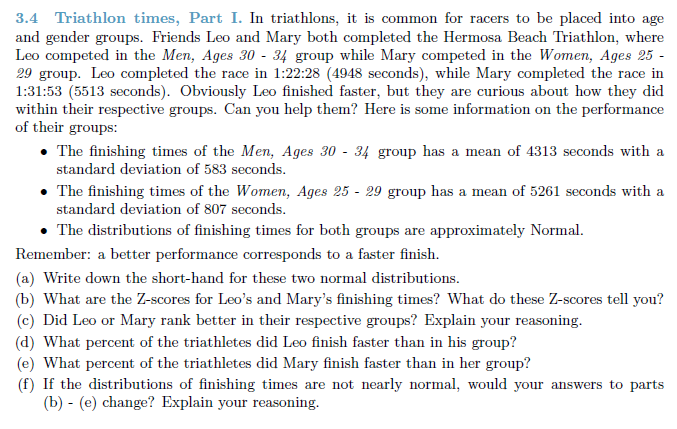

1. Men: $N(\mu = 4313, \sigma = 583)$ Women: $N(\mu = 5261, \sigma = 807)$
2. $Z(Leo) = \frac{4948 - 4313}{583} = 1.089194$ Leo performed one standard deviation slower than men in his age bracket. $Z(Mary) = \frac{5513 - 5261}{807} = 0.3122677$ Mary performed closer to the mean of her age bracket, making her the better performer.
3. Mary ranked better than Leo. She would have fallen roughly in the middle of her age bracket, while he finished slower than most of his bracket.
4. With a rounded Z-score of 1.09, `Table 3.8` says that `0.8621` of those in Leo’s age bracket finished faster than him (larger Z-score is worse performance). To find the percent of triathletes that *he* finished faster than we simply subtract it from 1. $1 - 0.8621 = 0.1379$
5. With a rounded Z-score of 0.31, `Table 3.8` says that `0.6217` of those in Mary’s age bracket finished faster than her. To find the percent of triathletes that *she* finished faster than we simply subtract it from 1. $1 - 0.6217 = 0.3783$
6. Yes, because likely the mean and standard deviations for both would also be different. If they didn’t change, then the Z-score would be the same, but we could no longer use the normal probability table to calculate percentages.

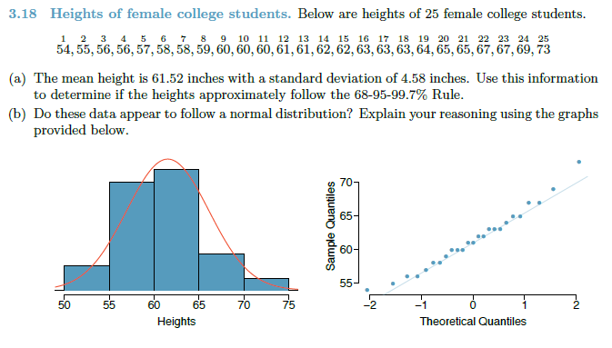

1. A simple method of seeing if the information follows the 68-95-99.7 rule is to just count the number of heights that fall within those standard deviations, then calculate what percentage that is.

```r
heights <- c(54, 55, 56, 56, 57, 58, 58, 59, 60, 60, 60, 61, 61, 62, 62, 63, 63, 63, 64, 65, 65, 67, 67, 69, 73)

m <- 61.52
sd <- 4.58

one.sd <- heights[(m - sd) < heights & heights < (m + sd)]
two.sd <- heights[(m - 2 * sd) < heights & heights < (m + 2 * sd)]
three.sd <- heights[(m - 3 * sd) < heights & heights < (m + 3 * sd)]

length(one.sd) / length(heights)
```

```
## [1] 0.68
```

```r
length(two.sd) / length(heights)
```

```
## [1] 0.96
```

```r
length(three.sd) / length(heights)
```

```
## [1] 1
```

Yes, this data seems to conform to the 68-95-99.7 rule, as it breaks down to `68-96-1`

2. I believe it’s close enough. It conforms to the 68-95-99.7 rule, and the graph is close to a normal distribution. The simulation plot has two extreme outliers, but the bulk remain near the line.

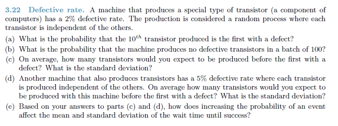

1. We decide that a “success” means finding a transistor with a defect. Using the **geometric distribution** we can calculate it as follows: $(1 - p)^{n-1}p$

```r
(1 - .02)^(10 - 1) * .02
```

```
## [1] 0.01667496
```

2. Due to the independence of production, we can simply multiply the probability of a successful transistor, `.98`, a hundred times.

```r
.98^100
```

```
## [1] 0.1326196
```

3. A success is a defect, so the probability is `0.02`, so to find the number of transistors we expect to be produced before a defect is simply $\frac{1}{p} = \frac{1}{0.02} = 50$. The standard deviation is $\sqrt{(1-p)/p^2} = \sqrt{(1 - 0.02) / 0.02^2}$

```r
sqrt((1 - 0.02) / 0.02^2)
```

```
## [1] 49.49747
```

4. The only thing that changes is the probability of producing a defect. Otherwise, we use the same equation as above.

```r
1/0.05
```

```
## [1] 20
```

```r
sqrt((1 - 0.05) / 0.05^2)
```

```
## [1] 19.49359
```

5. The average number of transistors produced until a defect is found lowers as the probability of producing a defect increases, which is what we’d expect to see. The standard deviation also lowers.

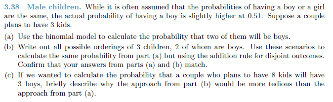

1. We will use the **binomial distribution**: ${n \choose k} p^k (1 - p)^{n - k}$. We are looking for three children with two boys.

```r
fac.boy <- factorial(3)/(factorial(2) * factorial(1))

fac.boy * 0.51^2 * (1-0.51)^(1)
```

```
## [1] 0.382347
```

2. `BBG BGB GBB` are the orderings for 3 children with 2 boys. Using the **disjoint rule** we’ll check our answer from a.

```r
(0.51 * 0.51 * 0.49) + (0.51 * 0.49 * 0.51) + (0.49 * 0.51 * 0.51)
```

```
## [1] 0.382347
```

Yes, they are equal.

3. For a, we would only need to substitute the values of `n` and `k` to `8` and `3`. For b, we would have to add a lot more combinations of boys and girls.

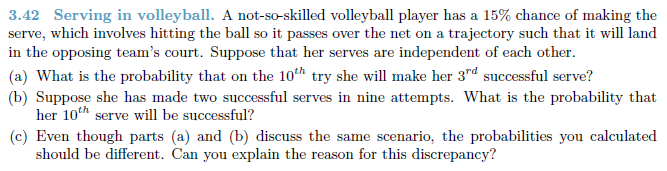

1. We will use the **negative binomial distribution**: ${n - 1 \choose k - 1} p^k (1 - p)^{n - k}$ with `n = 10` and `k = 3`

```r
fac <- factorial(9)/(factorial(2) * factorial(7))
fac * 0.15^3 * 0.85^7
```

```
## [1] 0.03895012
```

2. As the serves are independent, her probability of a success on the tenth serve is simply 0.15, or `p`. It’s the same as asking what is the odds of getting heads on the nth coin flip, given that you have two heads already. The other flips don’t matter.

If the question asked “What is the probability that she has three successful serves in ten attempts”, then we can utilize the **binomial distribution** to solve. In this situation, the answer would be:

```r
fac.serve <- factorial(10) / (factorial(3) * factorial(7))
fac.serve * 0.15^3 * 0.85^7
```

```
## [1] 0.1298337
```

3. Part a is asking for a specific ordering. It wants to know what is the probability that *on* the 10th try she will make her 3rd successful serve. Part b is more concerned with three successes in ten failures, and we can assume that the order doesn’t matter.